# RelaÃ§Ã£o entre votos, receitas, despesas e bens de candidatos

# Partidos

Alguns dados dos partidos mais comuns na PB

PT

```r
dados_candidatos %>%
  filter(`Sigla Partido` == "PT")
```

| Cargo | Sigla Partido | Sequencial Candidato | Numero candidato | Nome candidato | Turno | Situacao | Total votos | Total despesas | Total receitas | Total bens |
| --- | --- | --- | --- | --- | --- | --- | --- | --- | --- | --- |
| DEPUTADO FEDERAL | PT | 1,5e+11 | 1323 | JOSÉ LEONCIO DA SILVA JUNIOR | 1 | SUPLENTE | 2424 | 10036,63 | 10045,24 | NA |
| DEPUTADO FEDERAL | PT | 1,5e+11 | 1345 | LUIZ ALBUQUERQUE COUTO | 1 | ELEITO POR QP | 69922 | 402255,81 | 402402,66 | 71310,09 |
| DEPUTADO FEDERAL | PT | 1,5e+11 | 1301 | MARIA DAS GRAÇAS SANTIAGO SANTOS | 1 | SUPLENTE | 59 | NA | NA | NA |
| DEPUTADO FEDERAL | PT | 1,5e+11 | 1333 | ODON BEZERRA CAVALCANTI SOBRINHO | 1 | SUPLENTE | 22253 | 205243,25 | 205243,25 | 35000,00 |
| DEPUTADO FEDERAL | PT | 1,5e+11 | 1311 | RICARDO CARDOSO AGRA DE CASTRO | 1 | SUPLENTE | 878 | 9815,24 | 9815,24 | 20000,00 |
| DEPUTADO FEDERAL | PT | 1,5e+11 | 1300 | UBIRATAN PEREIRA DE OLIVEIRA | 1 | SUPLENTE | 12258 | 47277,87 | 47277,87 | 183022,10 |
| DEPUTADO FEDERAL | PT | 1,5e+11 | 1314 | JALES JAVA DOS SANTOS LACERDA CALIMAN | 1 | NÃO ELEITO | 0 | 800,00 | 800,00 | NA |

PSBD

```r
dados_candidatos%>%
filter(`Sigla Partido` == "PSDB")
```

| Cargo | Sigla Partido | Sequencial Candidato | Numero candidato | Nome candidato | Turno | Situacao | Total votos | Total despesas | Total receitas | Total bens |
| --- | --- | --- | --- | --- | --- | --- | --- | --- | --- | --- |
| DEPUTADO FEDERAL | PSDB | 1,5e+11 | 4555 | EDIRCE DE OLIVEIRA SILVA | 1 | SUPLENTE | 526 | 1004,00 | 1004,00 | NA |
| DEPUTADO FEDERAL | PSDB | 1,5e+11 | 4545 | EMERSON FERNANDES ALVINO PANTA | 1 | SUPLENTE | 25149 | 37994,06 | 37994,06 | 700000,0 |
| DEPUTADO FEDERAL | PSDB | 1,5e+11 | 4522 | IRAÊ HEUSI DE LUCENA NÓBREGA | 1 | SUPLENTE | 5353 | 47010,30 | 47010,66 | 888482,4 |
| DEPUTADO FEDERAL | PSDB | 1,5e+11 | 4515 | JOÃO BATISTA FREIRE VIEGAS | 1 | SUPLENTE | 1345 | 12717,61 | 9734,49 | NA |
| DEPUTADO FEDERAL | PSDB | 1,5e+11 | 4510 | PEDRO OLIVEIRA CUNHA LIMA | 1 | ELEITO POR QP | 179886 | 891070,46 | 891364,31 | 125674,0 |

DEM

```r
dados_candidatos%>%
filter(`Sigla Partido` == "DEM")
```

| Cargo | Sigla Partido | Sequencial Candidato | Numero candidato | Nome candidato | Turno | Situacao | Total votos | Total despesas | Total receitas | Total bens |
| --- | --- | --- | --- | --- | --- | --- | --- | --- | --- | --- |
| DEPUTADO FEDERAL | DEM | 1,5e+11 | 2539 | BENEDITA SIQUEIRA DE OLIVEIRA | 1 | SUPLENTE | 83 | 500,0 | 500 | NA |
| DEPUTADO FEDERAL | DEM | 1,5e+11 | 2511 | EFRAIM DE ARAÚJO MORAIS FILHO | 1 | ELEITO POR QP | 103477 | 881912,8 | 882050 | 893609,4 |

PMDB

```r
dados_candidatos %>%
  filter(`Sigla Partido` == "PMDB")
```

| Cargo | Sigla Partido | Sequencial Candidato | Numero candidato | Nome candidato | Turno | Situacao | Total votos | Total despesas | Total receitas | Total bens |
| --- | --- | --- | --- | --- | --- | --- | --- | --- | --- | --- |
| DEPUTADO FEDERAL | PMDB | 1,5e+11 | 1555 | ANDRÉ AUGUSTO CASTRO DO AMARAL FILHO | 1 | SUPLENTE | 6552 | 104000,64 | 104000,64 | NA |
| DEPUTADO FEDERAL | PMDB | 1,5e+11 | 1500 | EVISNALDO CRUZ DE ANDRADE | 1 | SUPLENTE | 2111 | 18866,67 | 18866,67 | NA |
| DEPUTADO FEDERAL | PMDB | 1,5e+11 | 1522 | HUGO MOTTA WANDERLEY DA NOBREGA | 1 | ELEITO POR QP | 123686 | 736525,81 | 742259,17 | 498458,0 |
| DEPUTADO FEDERAL | PMDB | 1,5e+11 | 1533 | JAQUELINE BARBOSA | 1 | SUPLENTE | 343 | 300,00 | 300,00 | NA |
| DEPUTADO FEDERAL | PMDB | 1,5e+11 | 1515 | MANOEL ALVES DA SILVA JUNIOR | 1 | ELEITO POR MÉDIA | 105693 | 1379298,27 | 1091562,32 | 1528793,9 |
| DEPUTADO FEDERAL | PMDB | 1,5e+11 | 1511 | MARIA AUXILIADORA SILVEIRA SANTOS | 1 | SUPLENTE | 1070 | 600,00 | 600,00 | NA |
| DEPUTADO FEDERAL | PMDB | 1,5e+11 | 1525 | MARIA CARMÉN SILVA CAVALCANTI DE ALBUQUERQUE | 1 | SUPLENTE | 154 | 600,00 | 600,00 | NA |
| DEPUTADO FEDERAL | PMDB | 1,5e+11 | 1510 | VENEZIANO VITAL DO RÊGO SEGUNDO NETO | 1 | ELEITO POR QP | 177680 | 1088197,33 | 1088197,33 | 287955,9 |

PSOL

```r
dados_candidatos %>%
  filter(`Sigla Partido` == "PSOL")
```

| Cargo | Sigla Partido | Sequencial Candidato | Numero candidato | Nome candidato | Turno | Situacao | Total votos | Total despesas | Total receitas | Total bens |
| --- | --- | --- | --- | --- | --- | --- | --- | --- | --- | --- |
| DEPUTADO FEDERAL | PSOL | 1,5e+11 | 5050 | RENAN PALMEIRA COSTA | 1 | NÃO ELEITO | 8240 | 6218,91 | 6350,0 | NA |
| DEPUTADO FEDERAL | PSOL | 1,5e+11 | 5014 | JOSÉ SILVA DOS SANTOS | 1 | NÃO ELEITO | 1698 | 2060,00 | 2105,0 | NA |
| DEPUTADO FEDERAL | PSOL | 1,5e+11 | 5024 | LILIAN PALMEIRA COSTA | 1 | NÃO ELEITO | 87 | 480,00 | 480,0 | NA |
| DEPUTADO FEDERAL | PSOL | 1,5e+11 | 5001 | MARIA JANETE GUEDES BELARMINO | 1 | NÃO ELEITO | 95 | 480,00 | 480,0 | 120000 |
| DEPUTADO FEDERAL | PSOL | 1,5e+11 | 5000 | LUIZ ANTÔNIO LÚCIO RANGEL | 1 | NÃO ELEITO | 48157 | 10374,40 | 10374,4 | NA |
| DEPUTADO FEDERAL | PSOL | 1,5e+11 | 5033 | DANIEL DIAS DE OLIVEIRA | 1 | NÃO ELEITO | 448 | 790,00 | 790,0 | NA |
| DEPUTADO FEDERAL | PSOL | 1,5e+11 | 5005 | SÍLVIO ROBERTO CALAÇO | 1 | NÃO ELEITO | 462 | 1850,00 | 1850,0 | 180000 |
| DEPUTADO FEDERAL | PSOL | 1,5e+11 | 5019 | MARIA MARTA LUCIA AIRES CAVALCANTE | 1 | NÃO ELEITO | 45 | NA | NA | NA |

# Análise das relações entre variáveis

Atraves da tecnica de Regreção vamos analisar algumas variaveis isoladas e como uma pode influenciar a outra.

Primeiro vamos começar com uma regreção simples

Esse gráfico abaixo representa a crescente dos totais de votos pela despesas dos candidatos.

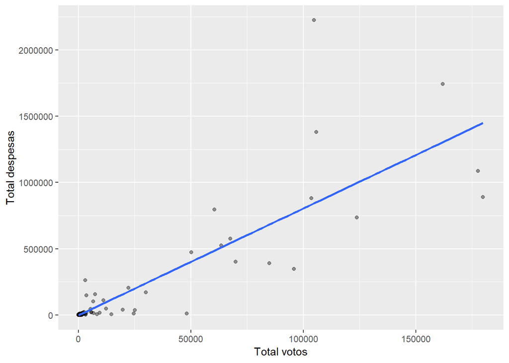

```r
ggplot(dados_candidatos, aes(x = `Total votos`, y = `Total despesas`)) +
  geom_point(alpha = 0.4) + geom_smooth(method = "lm", se = FALSE)
```

Esse grafico no permite dizer que, quanto menor as despesas, menor a quantidade de votos.

Vamos analisar agora o total de votos pelos total de bens dos cadidatos

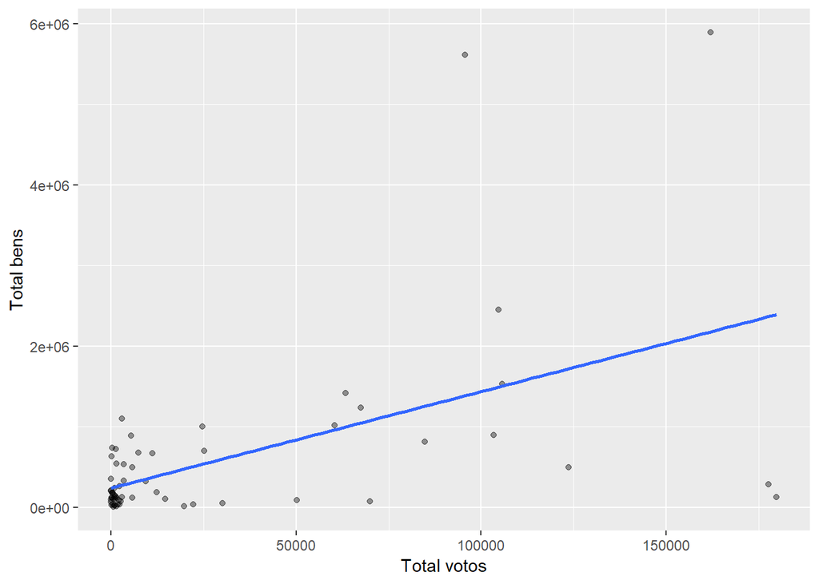

```r
ggplot(dados_candidatos, aes(x = `Total votos`, y = `Total bens`)) +
  geom_point(alpha = 0.4) + geom_smooth(method = "lm", se = FALSE)
```

Percebemos uma aglomeração, de dados abaixo de 50.000 mil votos, em cadidatos que declararam uma menor renda. Mas será que quanto precisa gastar um cadidato para ser eleito ?

Abaixo temos o gráfico feito atraves do Total de Votos X Total de Receita

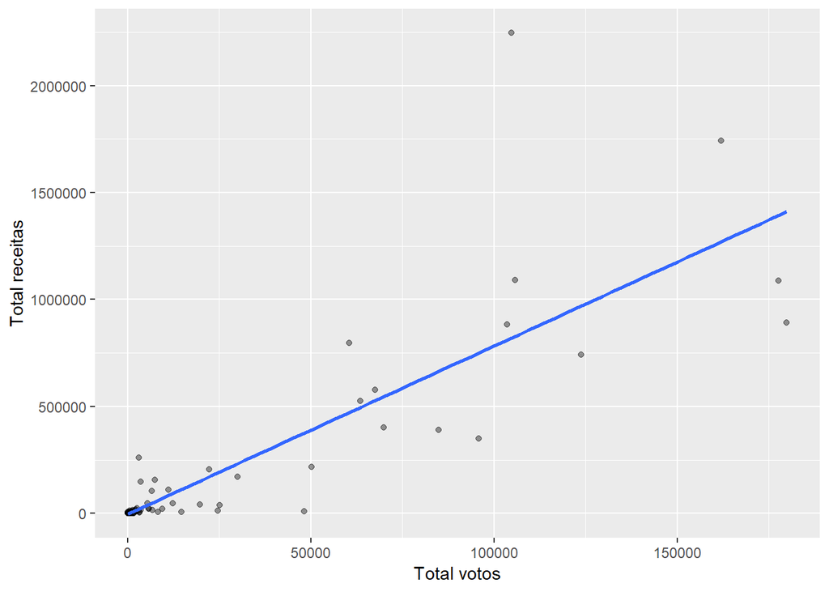

```r
ggplot(dados_candidatos, aes(x = `Total votos`, y = `Total receitas`)) +
  geom_point(alpha = 0.4) + geom_smooth(method = "lm", se = FALSE)
```

# Eleito, Ñ eleito, Suplente

Abaixo vemos um grafico de votação da Paraiba.

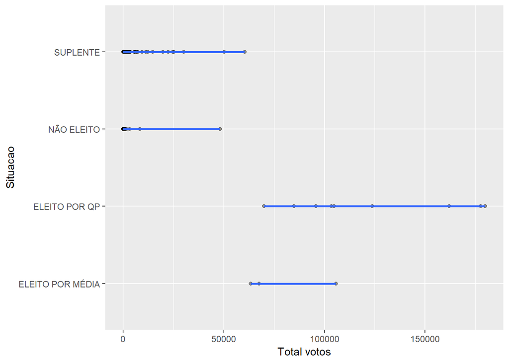

```r
ggplot(dados_candidatos, aes(x= `Total votos`, y= `Situacao`))+
  geom_point(alpha=0.4) + geom_smooth(method = "lm", se=FALSE)
```

Podemos concluir que para um cadidato seja eleito o mesmo tem que ter em média mais de 50 mil votos. Porém se olharmos com atenção, vemos que o número de suplente chega próximo ao número de eleitos por média, isso acorre pelas legendas dos candidatos, onde as mesmas puxam um determinado candidato pelo número de votos.

# Regressão

Mas será que estamos analizado de maneira correta e se sim nossa analize está eficiente para o contextu atual.

Utilizando a tecnica de regressão, podemos ver uma crescente quando queremos analizar o Total de votos pelo total de despesas. Para isso usamos o Modelo Linear responsavel por traçar uma reta (ou um semi reta) como forma de mostrar uma tendencia.

```r
modelo <- lm(`Total votos` ~ `Total despesas`, data = dados_candidatos)

  summary(modelo)
```

```
##
## Call:
## lm(formula = `Total votos` ~ `Total despesas`, data = dados_candidatos)
##
## Residuals:
##    Min     1Q Median     3Q    Max
## -99668  -6407  -5890     50  94084
##
## Coefficients:
##                   Estimate Std. Error t value Pr(>|t|)
## (Intercept)      6,504e+03  2,839e+03   2,291   0,0247 *
## `Total despesas` 8,899e-02  6,408e-03  13,888   <2e-16 ***
## ---
## Signif. codes:  0 '***' 0,001 '**' 0,01 '*' 0,05 '.' 0,1 ' ' 1
##
## Residual standard error: 22870 on 76 degrees of freedom
##   (18 observations deleted due to missingness)
## Multiple R-squared:  0,7173, Adjusted R-squared:  0,7136
## F-statistic: 192,9 on 1 and 76 DF,  p-value: < 2,2e-16
```

```r
  confint(modelo)
```

```
##                         2,5 %       97,5 %
## (Intercept)      850,28966272 12158,289830
## `Total despesas`   0,07622912     0,101754
```

```r
  tidy(modelo, confint= TRUE)
```

| term | estimate | std.error | statistic | p.value |
| --- | --- | --- | --- | --- |
| (Intercept) | 6,504290e+03 | 2,838820e+03 | 2,291195 | 2,472406e-02 |
| `Total despesas` | 8,899156e-02 | 6,407903e-03 | 13,887783 | 1,507825e-22 |

```r
  glance(modelo)
```

|  | r.squared | adj.r.squared | sigma | statistic | p.value | df | logLik | AIC | BIC | deviance | df.residual |
| --- | --- | --- | --- | --- | --- | --- | --- | --- | --- | --- | --- |
| 1 | 0,7173361 | 0,7136168 | 22871,33 | 192,8705 | 1,507825e-22 | 2 | -892,6001 | 1791,2 | 1798,27 | 39755442684 | 76 |

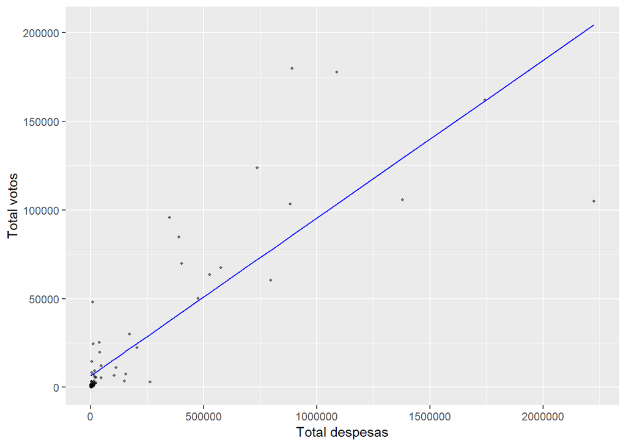

```r
  dados_candidatos %>%
    add_predictions(model = modelo) %>%
    ggplot(mapping = aes(x = `Total despesas`, y= `Total votos`)) +
    geom_point(alpha = 0.5, size = .8) +
    geom_line(aes(y = pred), colour = "blue")
```

Nessa analise com essas variaveis obtivemos um r² de 0,71, uma boa analise.

O mesmo foi usado para analisamos o total de votos atraves do total de receitas, e o resultado …

```r
modelo <- lm(`Total votos` ~ `Total receitas`, data = dados_candidatos)

  summary(modelo)
```

```
##
## Call:
## lm(formula = `Total votos` ~ `Total receitas`, data = dados_candidatos)
##
## Residuals:
##     Min      1Q  Median      3Q     Max
## -106377   -6637   -5854    -649   92017
##
## Coefficients:
##                   Estimate Std. Error t value Pr(>|t|)
## (Intercept)      6,740e+03  2,842e+03   2,371   0,0203 *
## `Total receitas` 9,102e-02  6,584e-03  13,823   <2e-16 ***
## ---
## Signif. codes:  0 '***' 0,001 '**' 0,01 '*' 0,05 '.' 0,1 ' ' 1
##
## Residual standard error: 22950 on 76 degrees of freedom
##   (18 observations deleted due to missingness)
## Multiple R-squared:  0,7154, Adjusted R-squared:  0,7117
## F-statistic: 191,1 on 1 and 76 DF,  p-value: < 2,2e-16
```

```r
  confint(modelo)
```

```
##                         2,5 %       97,5 %
## (Intercept)      1,079211e+03 1,240003e+04
## `Total receitas` 7,790291e-02 1,041311e-01
```

```r
  tidy(modelo, confint= TRUE)
```

| term | estimate | std.error | statistic | p.value |
| --- | --- | --- | --- | --- |
| (Intercept) | 6739,622359 | 2,842039e+03 | 2,371404 | 2,025405e-02 |
| `Total receitas` | 0,091017 | 6,584459e-03 | 13,823003 | 1,947418e-22 |

```r
  glance(modelo)
```

|  | r.squared | adj.r.squared | sigma | statistic | p.value | df | logLik | AIC | BIC | deviance | df.residual |
| --- | --- | --- | --- | --- | --- | --- | --- | --- | --- | --- | --- |
| 1 | 0,7154362 | 0,7116919 | 22948,07 | 191,0754 | 1,947418e-22 | 2 | -892,8613 | 1791,723 | 1798,793 | 40022652264 | 76 |

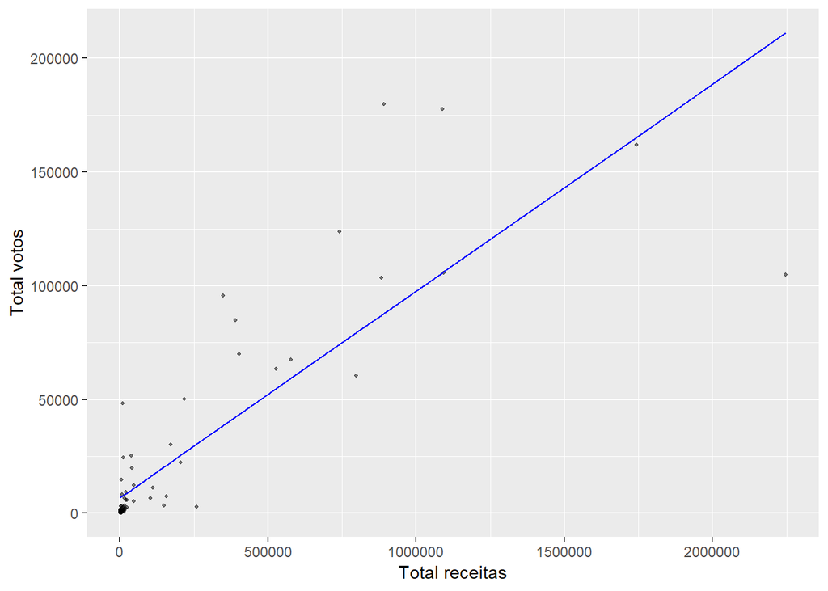

```r
  dados_candidatos %>%
    add_predictions(model = modelo) %>%
    ggplot(mapping = aes(x = `Total receitas`, y= `Total votos`)) +
    geom_point(alpha = 0.5, size = .8) +
    geom_line(aes(y = pred), colour = "blue")
```

Nessa analise com essas variaveis obtivemos um r² de 0,71, uma boa analise.

```r
modelo <- lm(`Total votos` ~ `Total bens`, data = dados_candidatos)

  summary(modelo)
```

```
##
## Call:
## lm(formula = `Total votos` ~ `Total bens`, data = dados_candidatos)
##
## Residuals:
##    Min     1Q Median     3Q    Max
## -48013 -17787 -14106   2104 163216
##
## Coefficients:
##               Estimate Std. Error t value Pr(>|t|)
## (Intercept)  1,376e+04  5,677e+03   2,423   0,0184 *
## `Total bens` 2,317e-02  4,791e-03   4,836 9,35e-06 ***
## ---
## Signif. codes:  0 '***' 0,001 '**' 0,01 '*' 0,05 '.' 0,1 ' ' 1
##
## Residual standard error: 39730 on 61 degrees of freedom
##   (33 observations deleted due to missingness)
## Multiple R-squared:  0,2771, Adjusted R-squared:  0,2653
## F-statistic: 23,39 on 1 and 61 DF,  p-value: 9,347e-06
```

```r
  confint(modelo)
```

```
##                     2,5 %       97,5 %
## (Intercept)  2,406164e+03 2,511162e+04
## `Total bens` 1,358833e-02 3,274685e-02
```

```r
  tidy(modelo, confint= TRUE)
```

| term | estimate | std.error | statistic | p.value |
| --- | --- | --- | --- | --- |
| (Intercept) | 1,375889e+04 | 5,677432e+03 | 2,423436 | 1,835627e-02 |
| `Total bens` | 2,316759e-02 | 4,790531e-03 | 4,836122 | 9,346874e-06 |

```r
  glance(modelo)
```

|  | r.squared | adj.r.squared | sigma | statistic | p.value | df | logLik | AIC | BIC | deviance | df.residual |
| --- | --- | --- | --- | --- | --- | --- | --- | --- | --- | --- | --- |
| 1 | 0,277149 | 0,265299 | 39731,66 | 23,38807 | 9,346874e-06 | 2 | -755,5408 | 1517,082 | 1523,511 | 96294887679 | 61 |

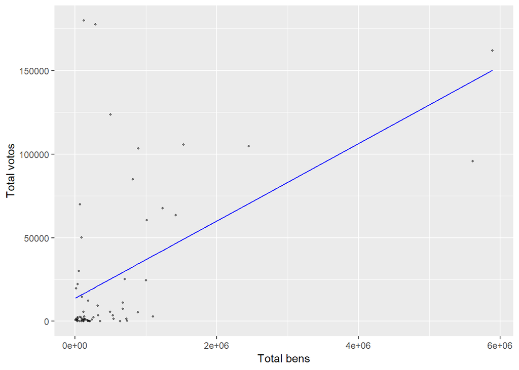

```r
  dados_candidatos %>%
    add_predictions(model = modelo) %>%
    ggplot(mapping = aes(x = `Total bens`, y= `Total votos`)) +
    geom_point(alpha = 0.5, size = .8) +
    geom_line(aes(y = pred), colour = "blue")
```

Nessa analise com essas variaveis obtivemos um r² de 0,27

# Analise Deputados Federais em PE

```r
# Filtre apenas o cargo que você está interessado em analisar. Exemplo:
dados_candidatos2 <- dados_candidatos2 %>%
  filter(Cargo == "DEPUTADO FEDERAL")

dados_candidatos2
```

| Cargo | Sigla Partido | Sequencial Candidato | Numero candidato | Nome candidato | Turno | Situacao | Total votos | Total despesas | Total receitas | Total bens |
| --- | --- | --- | --- | --- | --- | --- | --- | --- | --- | --- |
| DEPUTADO FEDERAL | DEM | 1,7e+11 | 2525 | JOSÉ MENDONÇA BEZERRA FILHO | 1 | ELEITO POR MÉDIA | 88250 | NA | NA | NA |
| DEPUTADO FEDERAL | PC do B | 1,7e+11 | 6540 | CARLOS EDUARDO CINTRA DA COSTA PEREIRA | 1 | SUPLENTE | 41226 | NA | NA | NA |
| DEPUTADO FEDERAL | PC do B | 1,7e+11 | 6510 | LUCIANA BARBOSA DE OLIVEIRA SANTOS | 1 | ELEITO POR MÉDIA | 85053 | NA | NA | NA |
| DEPUTADO FEDERAL | PCB | 1,7e+11 | 2121 | GERLANE SIMÕES BEZERRA | 1 | NÃO ELEITO | 918 | NA | NA | NA |
| DEPUTADO FEDERAL | PCB | 1,7e+11 | 2112 | EDVALMIR SOARES DA SILVA | 1 | NÃO ELEITO | 811 | NA | NA | NA |
| DEPUTADO FEDERAL | PCB | 1,7e+11 | 2111 | JERONIMO NEIVA NETO | 1 | NÃO ELEITO | 1573 | NA | NA | NA |
| DEPUTADO FEDERAL | PCB | 1,7e+11 | 2122 | ANTONIO DE CASTRO LIRA | 1 | NÃO ELEITO | 2813 | NA | NA | NA |
| DEPUTADO FEDERAL | PCB | 1,7e+11 | 2133 | SILVIA ALBUQUERQUE LEOCADIO | 1 | NÃO ELEITO | 35 | NA | NA | NA |
| DEPUTADO FEDERAL | PDT | 1,7e+11 | 1240 | MARILEIDE ROSENDO DE ALBUQUERQUE | 1 | SUPLENTE | 251 | NA | NA | NA |
| DEPUTADO FEDERAL | PDT | 1,7e+11 | 1212 | ISABELLA MENEZES DE ROLDÃO FIORENZANO | 1 | SUPLENTE | 33016 | NA | NA | NA |

[output cut: 145 more lines]

# Analise Exploratoria PE

Vamos fazer algumas analises exploratorias …

Deputado federal mais votado

```r
dados_candidatos2%>%
  top_n(1, `Total votos`)
```

| Cargo | Sigla Partido | Sequencial Candidato | Numero candidato | Nome candidato | Turno | Situacao | Total votos | Total despesas | Total receitas | Total bens |
| --- | --- | --- | --- | --- | --- | --- | --- | --- | --- | --- |
| DEPUTADO FEDERAL | PP | 1,7e+11 | 1111 | EDUARDO HENRIQUE DA FONTE DE ALBUQUERQUE SILVA | 1 | ELEITO POR QP | 283567 | NA | NA | NA |

Deputados federal menos votado

```r
dados_candidatos2%>%
  top_n(-1, `Total votos`)
```

| Cargo | Sigla Partido | Sequencial Candidato | Numero candidato | Nome candidato | Turno | Situacao | Total votos | Total despesas | Total receitas | Total bens |
| --- | --- | --- | --- | --- | --- | --- | --- | --- | --- | --- |
| DEPUTADO FEDERAL | PTB | 1,7e+11 | 1456 | GILSON MUNIZ DIAS | 1 | NÃO ELEITO | 0 | NA | NA | NA |
| DEPUTADO FEDERAL | PTB | 1,7e+11 | 1410 | CRISTIANO DE MELO VASCONCELOS BARROS | 1 | NÃO ELEITO | 0 | NA | NA | NA |
| DEPUTADO FEDERAL | PTC | 1,7e+11 | 3626 | JOSÉ ROBERTO TAVARES GADELHA | 1 | NÃO ELEITO | 0 | NA | NA | NA |

```r
dados_candidatos2 %>%
  top_n(1, `Total bens`)
```

| Cargo | Sigla Partido | Sequencial Candidato | Numero candidato | Nome candidato | Turno | Situacao | Total votos | Total despesas | Total receitas | Total bens |
| --- | --- | --- | --- | --- | --- | --- | --- | --- | --- | --- |

```r
dados_candidatos2 %>%
  top_n(-1, `Total despesas`)
```

| Cargo | Sigla Partido | Sequencial Candidato | Numero candidato | Nome candidato | Turno | Situacao | Total votos | Total despesas | Total receitas | Total bens |
| --- | --- | --- | --- | --- | --- | --- | --- | --- | --- | --- |

# Exemplos de perguntas a responder:

- Quanto um candidato deve gastar no mínimo (despesa) para ter mais chance de ser eleito?
- Quanto um candidato deve arrecadar no mínimo (receita) para ter mais chance de ser eleito?
- Quanto de bens um candidato deve ter no mínimo para ter mais chance de ser eleito?
- Existe alguma combinação de variáveis que explica bem a quantidade de dados que um candidato recebe?
- Considere um candidato fictício que recebeu 100 mil reais de receita na campanha. Qual a previsão de votos que ele deve receber? É provável que ele seja eleito?
- Considere um candidato fictício que gastou 100 mil reais de despesa na campanha e possui 1 milhão de reais em bens. Qual a previsão de votos que ele deve receber? É provável que ele seja eleito?